# Practical Machine Learning Project

Will Olson

12/10/2016

## Loading Data

First, I load the appropriate packages, and download/read in the training/testing data.

```r
library(caret); library(randomForest); library(rattle); library(lattice); library(ggplot2); library(gbm); library(survival); library(splines); library(parallel); library(plyr);
```

```r
##Loading in data
if (!file.exists("PML_Training.csv")){
    download.file(url="https://d396qusza40orc.cloudfront.net/predmachlearn/pml-training.csv", destfile="PML_Training.csv", method="curl")}
if (!file.exists("PML_Testing.csv")){
    download.file(url="https://d396qusza40orc.cloudfront.net/predmachlearn/pml-testing.csv", destfile="PML_Testing.csv", method="curl")}
training <- read.csv("PML_Training.csv")
testing <- read.csv("PML_Testing.csv")
```

## Cleaning Data

Now that the data is loaded in, I clean up the data by removing any variables containing NAs. Admittedly, I cheated a little bit for the sake of the final “testing” set to be used for the quiz. I narrowed down to only the variables in the testing set that do not contain NAs, and narrowed down to the same set of variables in the training set (plus the classe variable, which needs to be predicted for testing set). Conveniently, the nearZeroVar() function confirms thats there are no remaining variables that should be thrown out.

```r
#Remove first 7 columns, which shouldn't have any bearing on "classe"
testing <- testing[,-c(1:7)]
#Remove any columns with NAs
testing <- testing[, colSums(is.na(testing)) == 0]
#Training columns should mirror remaining testing columns
training <- training[, colnames(training) %in% c(colnames(testing),"classe")]
#nearZeroVar() confirms remaining variables are useful in constructing prediction model
nearZeroVar(training,saveMetrics=TRUE)
```

```
##                      freqRatio percentUnique zeroVar   nzv
## roll_belt             1.101904     6.7781062   FALSE FALSE
## pitch_belt            1.036082     9.3772296   FALSE FALSE
## yaw_belt              1.058480     9.9734991   FALSE FALSE
## total_accel_belt      1.063160     0.1477933   FALSE FALSE
## gyros_belt_x          1.058651     0.7134849   FALSE FALSE
## gyros_belt_y          1.144000     0.3516461   FALSE FALSE
## gyros_belt_z          1.066214     0.8612782   FALSE FALSE
## accel_belt_x          1.055412     0.8357966   FALSE FALSE
## accel_belt_y          1.113725     0.7287738   FALSE FALSE
## accel_belt_z          1.078767     1.5237998   FALSE FALSE
## magnet_belt_x         1.090141     1.6664968   FALSE FALSE
## magnet_belt_y         1.099688     1.5187035   FALSE FALSE
## magnet_belt_z         1.006369     2.3290184   FALSE FALSE
## roll_arm             52.338462    13.5256345   FALSE FALSE
## pitch_arm            87.256410    15.7323412   FALSE FALSE
## yaw_arm              33.029126    14.6570176   FALSE FALSE
## total_accel_arm       1.024526     0.3363572   FALSE FALSE
## gyros_arm_x           1.015504     3.2769341   FALSE FALSE
## gyros_arm_y           1.454369     1.9162165   FALSE FALSE
## gyros_arm_z           1.110687     1.2638875   FALSE FALSE
## accel_arm_x           1.017341     3.9598410   FALSE FALSE
## accel_arm_y           1.140187     2.7367241   FALSE FALSE
## accel_arm_z           1.128000     4.0362858   FALSE FALSE
## magnet_arm_x          1.000000     6.8239731   FALSE FALSE
## magnet_arm_y          1.056818     4.4439914   FALSE FALSE
## magnet_arm_z          1.036364     6.4468454   FALSE FALSE
## roll_dumbbell         1.022388    84.2065029   FALSE FALSE
## pitch_dumbbell        2.277372    81.7449801   FALSE FALSE
## yaw_dumbbell          1.132231    83.4828254   FALSE FALSE
## total_accel_dumbbell  1.072634     0.2191418   FALSE FALSE
## gyros_dumbbell_x      1.003268     1.2282132   FALSE FALSE
## gyros_dumbbell_y      1.264957     1.4167771   FALSE FALSE
## gyros_dumbbell_z      1.060100     1.0498420   FALSE FALSE
## accel_dumbbell_x      1.018018     2.1659362   FALSE FALSE
## accel_dumbbell_y      1.053061     2.3748853   FALSE FALSE
## accel_dumbbell_z      1.133333     2.0894914   FALSE FALSE
## magnet_dumbbell_x     1.098266     5.7486495   FALSE FALSE
## magnet_dumbbell_y     1.197740     4.3012945   FALSE FALSE
## magnet_dumbbell_z     1.020833     3.4451126   FALSE FALSE
## roll_forearm         11.589286    11.0895933   FALSE FALSE
## pitch_forearm        65.983051    14.8557741   FALSE FALSE
## yaw_forearm          15.322835    10.1467740   FALSE FALSE
## total_accel_forearm   1.128928     0.3567424   FALSE FALSE
## gyros_forearm_x       1.059273     1.5187035   FALSE FALSE
## gyros_forearm_y       1.036554     3.7763735   FALSE FALSE
## gyros_forearm_z       1.122917     1.5645704   FALSE FALSE
## accel_forearm_x       1.126437     4.0464784   FALSE FALSE
## accel_forearm_y       1.059406     5.1116094   FALSE FALSE
## accel_forearm_z       1.006250     2.9558659   FALSE FALSE
## magnet_forearm_x      1.012346     7.7667924   FALSE FALSE
## magnet_forearm_y      1.246914     9.5403119   FALSE FALSE
## magnet_forearm_z      1.000000     8.5771073   FALSE FALSE
## classe                1.469581     0.0254816   FALSE FALSE
```

## Data Partitioning

Next, I set the seed for reproducibility and create a data partition such that 75% of our data is used for training, and 25% is used for testing.

```r
set.seed(100)
inTrain <- createDataPartition(training$classe,p=0.75,list=FALSE)
train <- training[inTrain,]
test <- training[-inTrain,]
```

## Model Creation & Selection

I decide to try out 5 different training methods - each can be run by modifying the train() function and do not necessarily require the use of a separate function at all. If none of these seemed very accurate, I’d likely broaden my search.

1. gbm - Gradient Boosting
2. lda - Linear Discriminant Analysis
3. nb - Naive Bayes
4. rf - Random Forest
5. rpart - Classification and Regression Trees (CART)

I also set the control such that 5-fold cross validation takes place with each method. First, I train the algorithms based on the “train” data set, I then predict off the “test” data set, and evaluate the results using a confusion matrix for each method.

```r
#Set control for k-fold cross validation with k=5 folds
control <- trainControl(method="cv", number=5)
#Perform each of 5 methods on training set
fit_gbm <- train(classe~.,data=train,method="gbm",trControl=control)
fit_lda <- train(classe~.,data=train,method="lda",trControl=control)
fit_nb <- train(classe~.,data=train,method="nb",trControl=control)
fit_rpart <- train(classe~.,data=train,method="rpart",trControl=control)
fit_rf <- train(classe~.,data=train,method="rf",trControl=control,ntree=50)
```

```r
#Predict using each method on testing set
pred_gbm <- predict(fit_gbm,newdata=test)
pred_lda <- predict(fit_lda,newdata=test)
pred_nb <- predict(fit_nb,newdata=test)
pred_rpart <- predict(fit_rpart,newdata=test)
pred_rf <- predict(fit_rf,newdata=test)
```

```r
#Create confusion matrix for each prediction method
cm_gbm <- confusionMatrix(pred_gbm,test$classe)
cm_lda <- confusionMatrix(pred_lda,test$classe)
cm_nb <- confusionMatrix(pred_nb,test$classe)
cm_rpart <- confusionMatrix(pred_rpart,test$classe)
cm_rf <- confusionMatrix(pred_rf,test$classe)
```

Now that we have the info from each confusion matrix, I compare the accuracy of each method.

```r
#Compare accuracy of each method
accuracy <- data.frame(ModelType=c("gbm","lda","nb","rpart","rf"), Accuracy=rbind(cm_gbm$overall[1],cm_lda$overall[1],cm_nb$overall[1],cm_rpart$overall[1],cm_rf$overall[1]))
accuracy
```

```
##   ModelType  Accuracy
## 1       gbm 0.9612561
## 2       lda 0.7000408
## 3        nb 0.7483687
## 4     rpart 0.4889886
## 5        rf 0.9936786
```

As you can see, Naive Bayes, Linear Discriminant Analysis, and CART do not perform prediction very well based on their accuracy (see Appendix A for classification tree from CART). All three are below 75% accuracy, and CART is even below 50%.

However, the boosting and random forest methods perform much better, each predicting classe with more than 95% accuracy. However, the random forest method predicts classe with over 99% accuracy in the test set, so an out-of-sample error of less than 1%. Therefore, I decide to use this method on the testing data set for the project quiz (it predicted 20/20 correct). These results aren’t too surprising since random forest and boosting methods are some of the most accurate/widely used prediction algorithms (see Appendix B-D for random forest exploratory analysis).

I also want to note one quick thing - although the random forest method was most accurate of the 5 that I tested, it also took the longest time to run, and produced 50+ warning messages. I’m not sure if I could reduce the value of ntrees to reduce the run time without sacrificing much accuracy, but it seems like you could get comparable accuracy by boosting (95% vs 99%) in much less time. While I ended up using the random forest method on the testing data, this is worth consideration if time was an issue.

## Appendix

### A) Classification tree from CART method

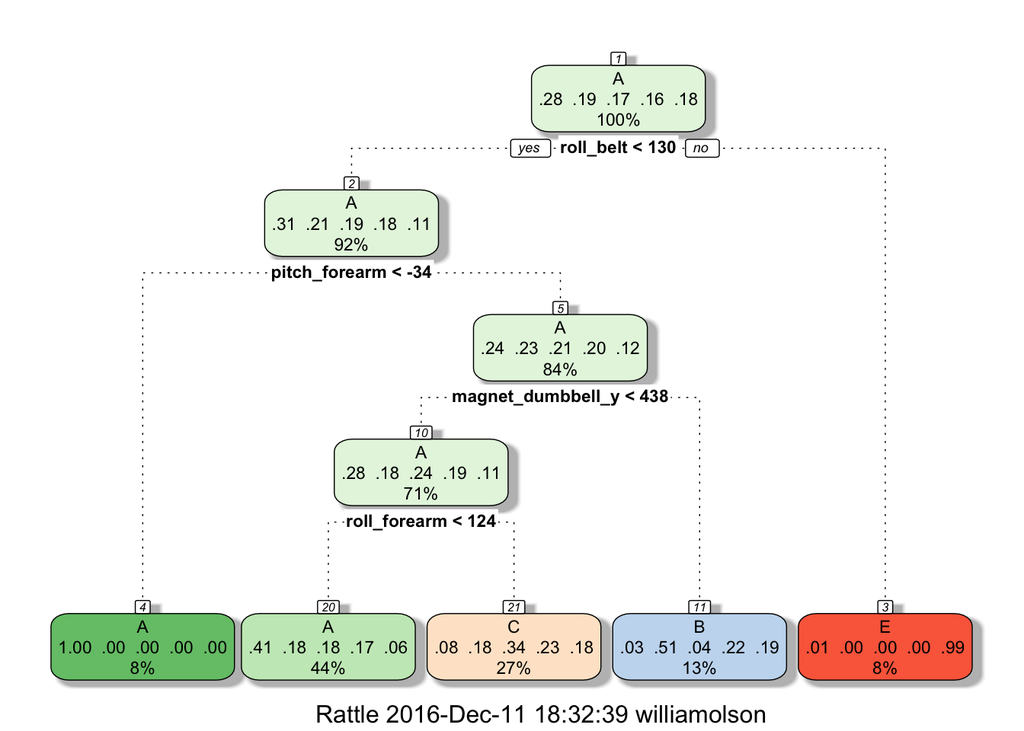

```r
#Create plot for CART method
fancyRpartPlot(fit_rpart$finalModel)
```

### B) Most Important Variables from Random Forest Method

```r
test$predRight <- pred_rf==test$classe
varImp(fit_rf)
```

```
## rf variable importance
##
##   only 20 most important variables shown (out of 52)
##
##                   Overall
## roll_belt          100.00
## yaw_belt            69.94
## magnet_dumbbell_z   64.27
## pitch_forearm       59.04
## magnet_dumbbell_y   58.93
## pitch_belt          55.57
## magnet_dumbbell_x   50.92
## magnet_belt_z       44.51
## roll_dumbbell       43.58
## magnet_belt_y       41.37
## accel_dumbbell_y    40.01
## accel_belt_z        39.95
## roll_forearm        38.86
## accel_dumbbell_z    34.84
## roll_arm            34.31
## gyros_dumbbell_y    27.33
## accel_forearm_x     26.82
## gyros_belt_z        25.02
## magnet_arm_y        23.49
## yaw_arm             23.14
```

### C) Distribution of Classe in Test Set

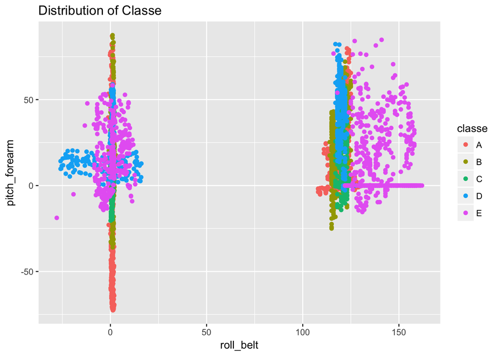

```r
qplot(roll_belt,pitch_forearm,colour=classe,data=test,main="Distribution of Classe")
```

### D) Prediction Accuracy of Random Forest Method

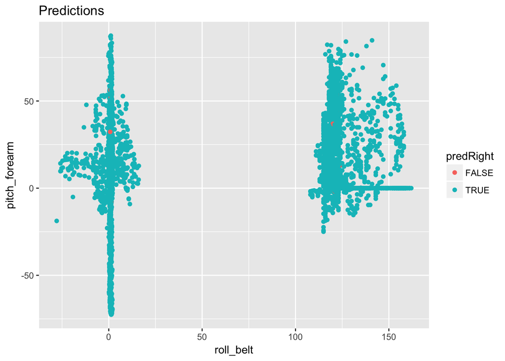

```r
qplot(roll_belt,pitch_forearm,colour=predRight,data=test,main="Predictions")
```